# Return Home

[View Code on Github](https://github.com/JohnKimaiyo/Data-Analysis-Projects/blob/main/Youtube%20API/Cloud%20ERP%20You%20Tube%20Stats.ipynb)

# Cloud ERP You Tube Stats

## 1 Oracle ERP

We’re a cloud technology company that provides organizations around the world with computing infrastructure and software to help them innovate, unlock efficiencies and become more effective. We also created the world’s first–and only–autonomous database to help organize and secure our customers’ data. From nonprofits to companies of all sizes, millions of people use our tools to streamline supply chains, make HR more human, quickly pivot to a new financial plan, and connect data and people around the world.

## 2 Microsoft Dynamics 365 Business Central

Microsoft Dynamics 365 Business Central is a comprehensive business management solution that helps small and midsized companies connect their finance, sales, service, and operations teams within a single easy-to-use application. Confidently move to the cloud and unlock the insights needed to adapt faster, work smarter, and perform better.

## 3 SAP software

SAP SE is a German multinational software company based in Walldorf, Baden-Württemberg. It develops enterprise software to manage business operations and customer relations.

## 4 Sage Intacct

Sage Intacct

## 5 Odoo ERP

Odoo is the #1 open source integrated business apps suite. Main apps include Website Builder, eCommerce, CRM, Accounting, Project Management, Warehouse Management, Manufacturing, Human Resources, and Marketing. There is an app for everything you need to manage your business, supported by the largest business app store in the world (https://odoo.com/apps)!

```python
# lets import libraries
from googleapiclient.discovery import build
import pandas as pd
import seaborn as sns
```

## 1 Oracle ERP

```python
api_key = 'AIzaSyB24Kop04L1GlTgRCm1XtQ4KB2a4gaBOwA'
Oracle_ERP_channel_id = ['UCHCThmyZ-2yWkv0UVeBDdnQ' # Oracle ERP

              ]
youtube = build('youtube','v3',developerKey = api_key)

from googleapiclient.errors import HttpError

def get_channel_stats(youtube,Oracle_ERP_channel_id):
    all_data = []
    try:
        request = youtube.channels().list(
            part='snippet,contentDetails,statistics',
            id=','.join(Oracle_ERP_channel_id)
        )
        response = request.execute()

        for item in response.get('items', []):
            snippet = item.get('snippet', {})
            statistics = item.get('statistics', {})

            data = {
                'Channel_name': snippet.get('title', ''),
                'Subscribers': statistics.get('subscriberCount', ''),
                'Views': statistics.get('viewCount', ''),
                'Total_videos': statistics.get('videoCount', '')
            }

            all_data.append(data)

    except HttpError as e:
        print(f"HTTP error occurred: {e}")
        print(f"Request URL: {e.resp.request.url}")
        print(f"Request body: {e.resp.request.body}")

    return all_data
```

```python
get_channel_stats(youtube,Oracle_ERP_channel_id)
```

```
[{'Channel_name': 'Oracle',
  'Subscribers': '126000',
  'Views': '35836919',
  'Total_videos': '4352'}]
```

```python
channel_statistics = get_channel_stats(youtube, Oracle_ERP_channel_id)
```

```python
Oracle_ERP_channel_data =pd.DataFrame(channel_statistics)
```

```python
Oracle_ERP_channel_data
```

|  | Channel_name | Subscribers | Views | Total_videos |
| --- | --- | --- | --- | --- |
| 0 | Oracle | 126000 | 35836919 | 4352 |

## 2 Microsoft Dynamics 365 Business Central

```python
api_key = 'AIzaSyB24Kop04L1GlTgRCm1XtQ4KB2a4gaBOwA'
Microsoft_Dynamics_channel_id = ['UCJGCg4rB3QSs8y_1FquelBQ' # ## 2 Microsoft Dynamics 365 Business Central

              ]
youtube = build('youtube','v3',developerKey = api_key)

from googleapiclient.errors import HttpError

def get_channel_stats(youtube, Microsoft_Dynamics_channel_id ):
    all_data = []
    try:
        request = youtube.channels().list(
            part='snippet,contentDetails,statistics',
            id=','.join(Microsoft_Dynamics_channel_id )
        )
        response = request.execute()

        for item in response.get('items', []):
            snippet = item.get('snippet', {})
            statistics = item.get('statistics', {})

            data = {
                'Channel_name': snippet.get('title', ''),
                'Subscribers': statistics.get('subscriberCount', ''),
                'Views': statistics.get('viewCount', ''),
                'Total_videos': statistics.get('videoCount', '')
            }

            all_data.append(data)

    except HttpError as e:
        print(f"HTTP error occurred: {e}")
        print(f"Request URL: {e.resp.request.url}")
        print(f"Request body: {e.resp.request.body}")

    return all_data
```

```python
get_channel_stats(youtube, Microsoft_Dynamics_channel_id)
```

```
[{'Channel_name': 'Microsoft Dynamics 365',
  'Subscribers': '79500',
  'Views': '5195476',
  'Total_videos': '621'}]
```

```python
channel_statistics = get_channel_stats(youtube, Microsoft_Dynamics_channel_id)
```

```python
Microsoft_Dynamics_channel_data =pd.DataFrame(channel_statistics)
```

```python
Microsoft_Dynamics_channel_data
```

|  | Channel_name | Subscribers | Views | Total_videos |
| --- | --- | --- | --- | --- |
| 0 | Microsoft Dynamics 365 | 79500 | 5195476 | 621 |

## 3 SAP software

```python
api_key = 'AIzaSyB24Kop04L1GlTgRCm1XtQ4KB2a4gaBOwA'
SAP_software_channel_id = ['UCVnIv2xF2wyMMCSKv1qF3pA' # SAP_software

              ]
youtube = build('youtube','v3',developerKey = api_key)

from googleapiclient.errors import HttpError

def get_channel_stats(youtube, SAP_software_channel_id):
    all_data = []
    try:
        request = youtube.channels().list(
            part='snippet,contentDetails,statistics',
            id=','.join(SAP_software_channel_id)
        )
        response = request.execute()

        for item in response.get('items', []):
            snippet = item.get('snippet', {})
            statistics = item.get('statistics', {})

            data = {
                'Channel_name': snippet.get('title', ''),
                'Subscribers': statistics.get('subscriberCount', ''),
                'Views': statistics.get('viewCount', ''),
                'Total_videos': statistics.get('videoCount', '')
            }

            all_data.append(data)

    except HttpError as e:
        print(f"HTTP error occurred: {e}")
        print(f"Request URL: {e.resp.request.url}")
        print(f"Request body: {e.resp.request.body}")

    return all_data
```

```python
get_channel_stats(youtube, SAP_software_channel_id)
```

```
[{'Channel_name': 'SAP',
  'Subscribers': '107000',
  'Views': '49305839',
  'Total_videos': '1058'}]
```

```python
channel_statistics = get_channel_stats(youtube, SAP_software_channel_id)
```

```python
SAP_software_channel_data =pd.DataFrame(channel_statistics)
```

```python
SAP_software_channel_data
```

|  | Channel_name | Subscribers | Views | Total_videos |
| --- | --- | --- | --- | --- |
| 0 | SAP | 107000 | 49305839 | 1058 |

## 4 Sage Intacct

```python
api_key = 'AIzaSyB24Kop04L1GlTgRCm1XtQ4KB2a4gaBOwA'
Sage_Intacct_channel_id = ['UC1rfnyYzmBGaUK6Av8hN5SQ' # Sage Intacct

              ]
youtube = build('youtube','v3',developerKey = api_key)

from googleapiclient.errors import HttpError

def get_channel_stats(youtube, Sage_Intacct_channel_id):
    all_data = []
    try:
        request = youtube.channels().list(
            part='snippet,contentDetails,statistics',
            id=','.join(Sage_Intacct_channel_id)
        )
        response = request.execute()

        for item in response.get('items', []):
            snippet = item.get('snippet', {})
            statistics = item.get('statistics', {})

            data = {
                'Channel_name': snippet.get('title', ''),
                'Subscribers': statistics.get('subscriberCount', ''),
                'Views': statistics.get('viewCount', ''),
                'Total_videos': statistics.get('videoCount', '')
            }

            all_data.append(data)

    except HttpError as e:
        print(f"HTTP error occurred: {e}")
        print(f"Request URL: {e.resp.request.url}")
        print(f"Request body: {e.resp.request.body}")

    return all_data
```

```python
get_channel_stats(youtube, Sage_Intacct_channel_id)
```

```
[{'Channel_name': 'Sage Intacct, Inc.',
  'Subscribers': '1810',
  'Views': '305662',
  'Total_videos': '132'}]
```

```python
channel_statistics = get_channel_stats(youtube, Sage_Intacct_channel_id)
```

```python
Sage_Intacct_channel_data =pd.DataFrame(channel_statistics)
```

```python
Sage_Intacct_channel_data
```

|  | Channel_name | Subscribers | Views | Total_videos |
| --- | --- | --- | --- | --- |
| 0 | Sage Intacct, Inc. | 1810 | 305662 | 132 |

## 5 Odoo ERP

```python
api_key = 'AIzaSyB24Kop04L1GlTgRCm1XtQ4KB2a4gaBOwA'
Odoo_ERP_channel_id = ['UCkQPikELWZFLgQNHd73jkdg' # Odoo ERP

              ]
youtube = build('youtube','v3',developerKey = api_key)

from googleapiclient.errors import HttpError

def get_channel_stats(youtube, Odoo_ERP_channel_id):
    all_data = []
    try:
        request = youtube.channels().list(
            part='snippet,contentDetails,statistics',
            id=','.join(Odoo_ERP_channel_id)
        )
        response = request.execute()

        for item in response.get('items', []):
            snippet = item.get('snippet', {})
            statistics = item.get('statistics', {})

            data = {
                'Channel_name': snippet.get('title', ''),
                'Subscribers': statistics.get('subscriberCount', ''),
                'Views': statistics.get('viewCount', ''),
                'Total_videos': statistics.get('videoCount', '')
            }

            all_data.append(data)

    except HttpError as e:
        print(f"HTTP error occurred: {e}")
        print(f"Request URL: {e.resp.request.url}")
        print(f"Request body: {e.resp.request.body}")

    return all_data
```

```python
get_channel_stats(youtube, Odoo_ERP_channel_id)
```

```
[{'Channel_name': 'Odoo',
  'Subscribers': '177000',
  'Views': '28515917',
  'Total_videos': '3446'}]
```

```python
channel_statistics = get_channel_stats(youtube, Odoo_ERP_channel_id)
```

```python
Odoo_ERP_channel_data =pd.DataFrame(channel_statistics)
```

```python
Odoo_ERP_channel_data
```

|  | Channel_name | Subscribers | Views | Total_videos |
| --- | --- | --- | --- | --- |
| 0 | Odoo | 177000 | 28515917 | 3446 |

```python
# Combine DataFrames using concat
combined_cloud_ERP_channels_df = pd.concat([
                                        Oracle_ERP_channel_data,
                                     Microsoft_Dynamics_channel_data,
                                      SAP_software_channel_data ,
                                       Sage_Intacct_channel_data ,
                                       Odoo_ERP_channel_data,
                                      ], ignore_index=True)

# Display the result
print(combined_cloud_ERP_channels_df)
```

```
             Channel_name Subscribers     Views Total_videos
0                  Oracle      126000  35836919         4352
1  Microsoft Dynamics 365       79500   5195476          621
2                     SAP      107000  49305839         1058
3      Sage Intacct, Inc.        1810    305662          132
4                    Odoo      177000  28515917         3446
```

```python
# lets have  a look at the datatypes
combined_cloud_ERP_channels_df.info()
```

```
<class 'pandas.core.frame.DataFrame'>
RangeIndex: 5 entries, 0 to 4
Data columns (total 4 columns):
 #   Column        Non-Null Count  Dtype
---  ------        --------------  -----
 0   Channel_name  5 non-null      object
 1   Subscribers   5 non-null      object
 2   Views         5 non-null      object
 3   Total_videos  5 non-null      object
dtypes: object(4)
memory usage: 292.0+ bytes
```

```python
# lets change the datatypes to perform  visualisations
combined_cloud_ERP_channels_df['Subscribers'] = pd.to_numeric(combined_cloud_ERP_channels_df['Subscribers'])
combined_cloud_ERP_channels_df['Views'] = pd.to_numeric(combined_cloud_ERP_channels_df['Views'])
combined_cloud_ERP_channels_df['Total_videos'] = pd.to_numeric(combined_cloud_ERP_channels_df['Total_videos'])
# letsconirm if the datatypes has changed
combined_cloud_ERP_channels_df.info()
```

```
<class 'pandas.core.frame.DataFrame'>
RangeIndex: 5 entries, 0 to 4
Data columns (total 4 columns):
 #   Column        Non-Null Count  Dtype
---  ------        --------------  -----
 0   Channel_name  5 non-null      object
 1   Subscribers   5 non-null      int64
 2   Views         5 non-null      int64
 3   Total_videos  5 non-null      int64
dtypes: int64(3), object(1)
memory usage: 292.0+ bytes
```

```python
combined_cloud_ERP_channels_df
```

|  | Channel_name | Subscribers | Views | Total_videos |
| --- | --- | --- | --- | --- |
| 0 | Oracle | 126000 | 35836919 | 4352 |
| 1 | Microsoft Dynamics 365 | 79500 | 5195476 | 621 |
| 2 | SAP | 107000 | 49305839 | 1058 |
| 3 | Sage Intacct, Inc. | 1810 | 305662 | 132 |
| 4 | Odoo | 177000 | 28515917 | 3446 |

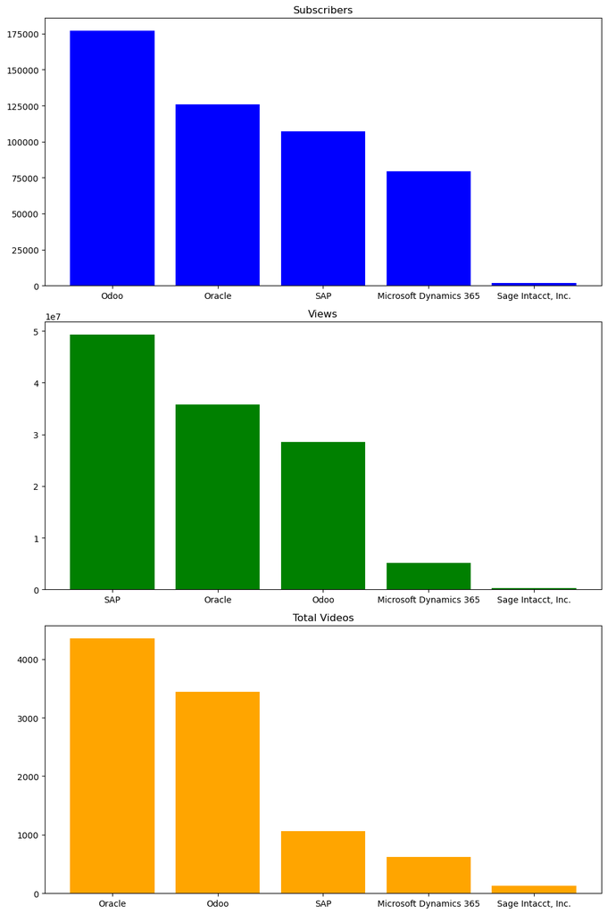

```python
import matplotlib.pyplot as plt

# Sort the DataFrame by 'Subscribers' in descending order
combined_cloud_ERP_channels_df_subscribers_sorted =combined_cloud_ERP_channels_df.sort_values(by='Subscribers', ascending=False)

# Plotting Subscribers in descending order
fig, axes = plt.subplots(nrows=3, ncols=1, figsize=(10, 15))

axes[0].bar(combined_cloud_ERP_channels_df_subscribers_sorted['Channel_name'], combined_cloud_ERP_channels_df_subscribers_sorted['Subscribers'], color='blue')
axes[0].set_title('Subscribers')

# Sort the DataFrame by 'Views' in descending order
combined_cloud_ERP_channels_df_views_sorted = combined_cloud_ERP_channels_df.sort_values(by='Views', ascending=False)

# Plotting Views in descending order
axes[1].bar(combined_cloud_ERP_channels_df_views_sorted['Channel_name'], combined_cloud_ERP_channels_df_views_sorted['Views'], color='green')
axes[1].set_title('Views')

# Sort the DataFrame by 'Total_videos' in descending order
combined_cloud_ERP_channels_df_total_videos_sorted = combined_cloud_ERP_channels_df.sort_values(by='Total_videos', ascending=False)

# Plotting Total Videos in descending order
axes[2].bar(combined_cloud_ERP_channels_df_total_videos_sorted['Channel_name'], combined_cloud_ERP_channels_df_total_videos_sorted['Total_videos'], color='orange')
axes[2].set_title('Total Videos')

# Adjust layout for better visibility
plt.tight_layout()

# Show the plot
plt.show()
```